# Class 5 - In class exercises

Ian Hollands

Date created: 2019-03-21

**CHEATSHEETS**

1. [Data visualization](https://github.com/rstudio/cheatsheets/blob/master/data-visualization-2.1.pdf)
2. [Data Manipulation](https://github.com/rstudio/cheatsheets/blob/master/data-transformation.pdf)

**KEYBOARD SHORTCUTS**:

1. Assignment operator (<-) is `Alt+-` for Windows and `Option+-` for Mac
2. Insert new code chunk `Ctrl+Alt+I` for Windows and `Command+Option+I` for Mac
3. Run a line of code `Ctrl+Enter` for Windows and `Command+Enter` for Mac
4. Run all the code within a chunk `Ctrl+Shift+Enter` for Windows and `Command+Shift+Enter` for Mac
5. Insert a pipe operator (%>%) `Ctrl+Shift+M` for Windows and `Command+Shift+M` for Mac

## Task Set 1: Create simple charts

1. Create a histogram of arrival delay.

```r
library(tidyverse); library(nycflights13)
```

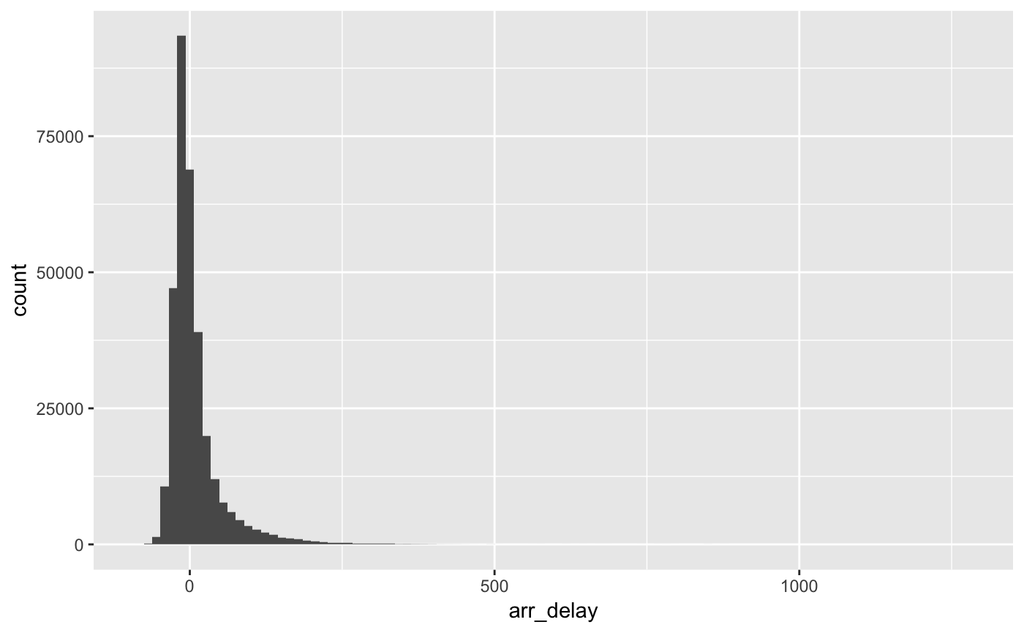

```r
ggplot(flights, aes(arr_delay)) +
  geom_histogram(bins=100)
```

2. Run the following code to create a stacked column chart. Set the argument position for `geom_col()` to “dodge” to display these bars next to each other instead of on top of each other.

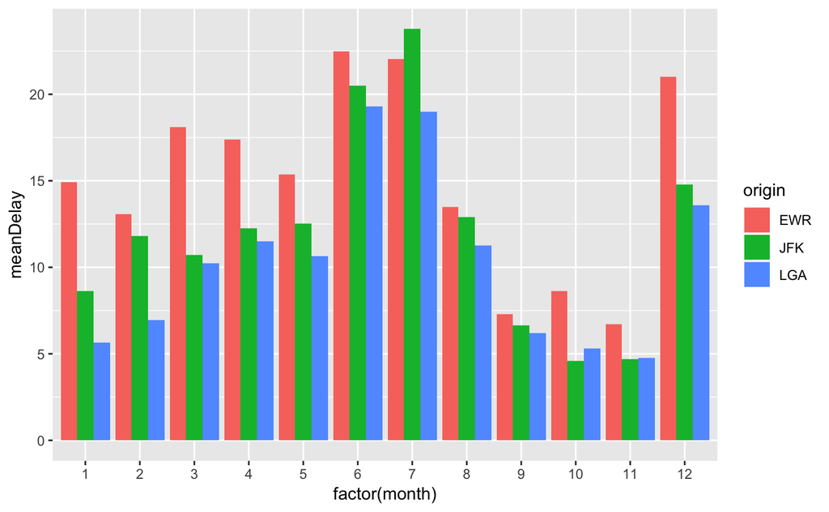

```r
flights %>%
    group_by(origin, month) %>%
    summarise(meanDelay = mean(dep_delay, na.rm = T)) %>%
    ggplot(aes(x = factor(month), y = meanDelay, fill = origin)) +
    geom_col(position = 'dodge')
```

4. Create a scatter plot that compares arrival delay with departure delay. How would you describe the relationship between the two variables?

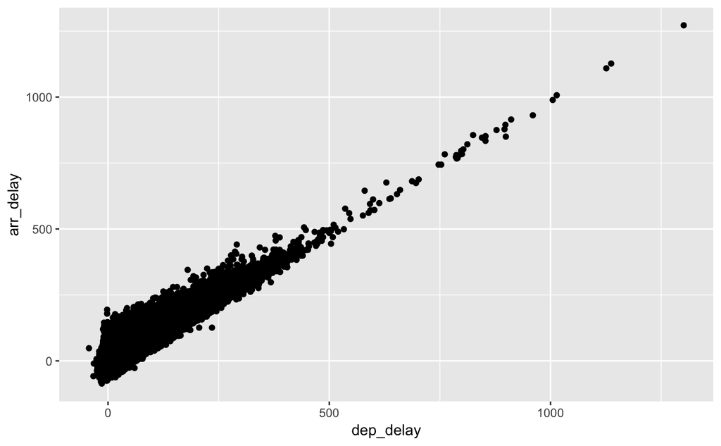

```r
ungroup(flights) %>%
  ggplot(aes(x = dep_delay, y = arr_delay)) +
  geom_point()
```

5. Group the data by `day` to calculate the mean departure delay and pipe to a ggplot to create a line chart showing `day` on the x-axis and the mean departure delay on the y-axis. What questions come up when you look at this chart?

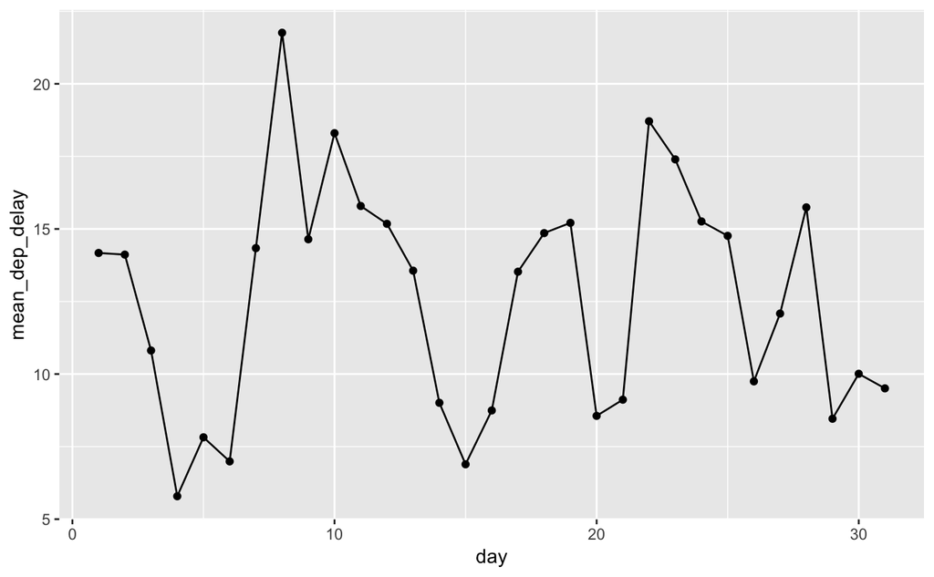

```r
flights %>%
  group_by(day) %>%
  summarise(mean_dep_delay = mean(dep_delay, na.rm = T)) %>%
  ggplot(aes(x = day, y = mean_dep_delay)) +
  geom_line() +
  geom_point()
```

## Task Set 2: Facets and multiple geoms

1. Create a facetted version of the histogram you made in the previous task set. You can pick a facet of your choice (remember that a facet should be a categorical variable)

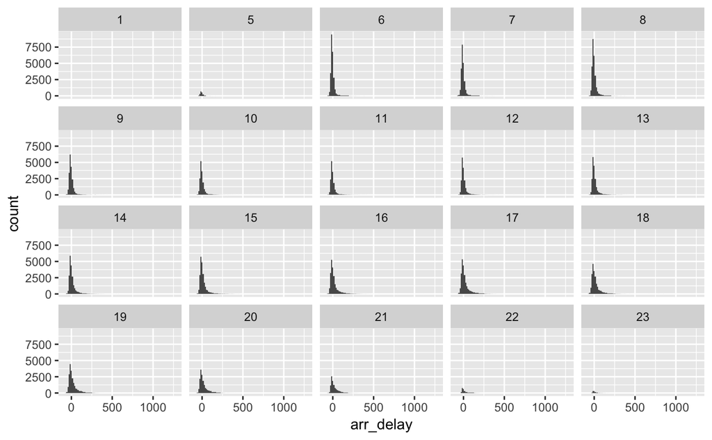

```r
ggplot(flights, aes(arr_delay)) +
  geom_histogram(bins=100) +
  facet_wrap(~hour)
```

2. The code below is the same as task 3 in the previous task set. Modify it to create a facetted version of the chart (instead of the stacked bars). Think about what variable you should use to facet.

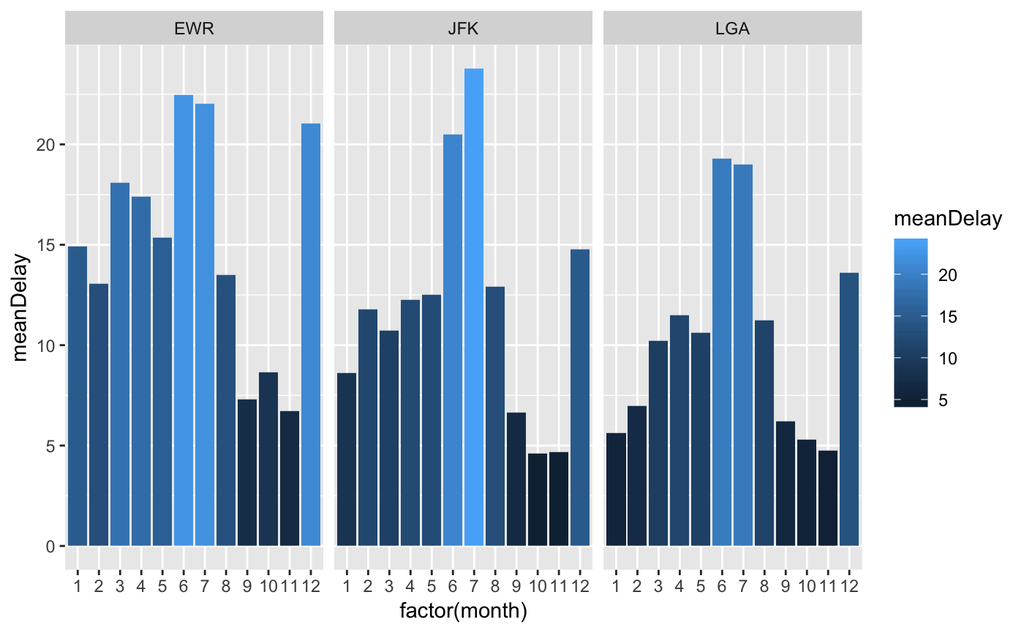

```r
flights %>%
    group_by(origin, month) %>%
    summarise(meanDelay = mean(dep_delay, na.rm = T)) %>%
    ggplot(aes(x = factor(month), y = meanDelay, fill = meanDelay)) +
    geom_col() +
    facet_wrap(~origin)
```

3. Extend the scatter plot you made in the previous section by adding a `geom_smooth()` to it.

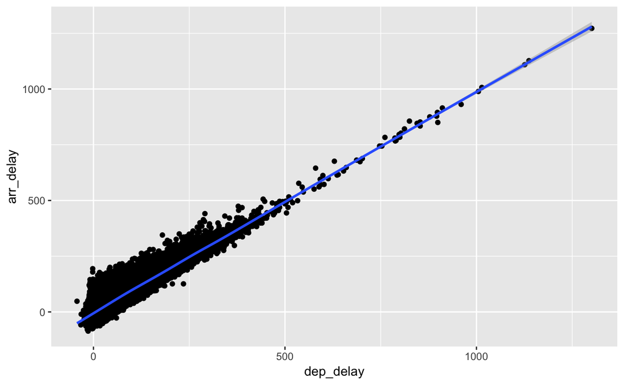

```r
flights %>%
  ggplot(aes(x = dep_delay, y = arr_delay)) +
  geom_point() +
  geom_smooth()
```

4. How would you make the line generated by `geom_smooth()` linear (i.e. a straight line)

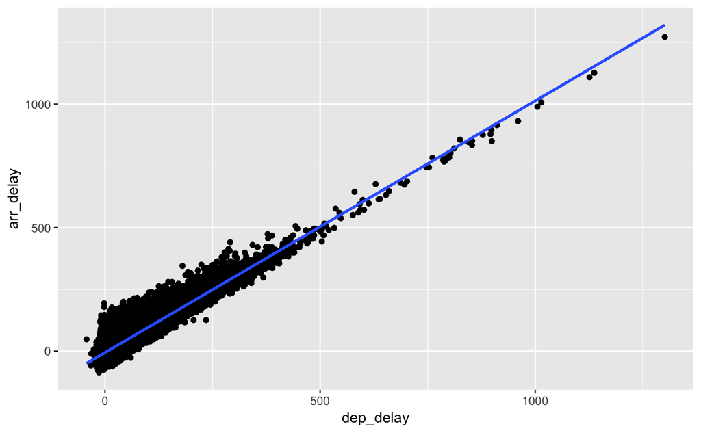

```r
flights %>%
  ggplot(aes(x = dep_delay, y = arr_delay)) +
  geom_point() +
  geom_smooth(method = 'lm')
```

## Task Set 3: Make a pretty plot

1. Take any plot that you made in any of the previous set of tasks and
   - Add axis labels and chart title
   - Any additional aesthetics to make it prettier
   - Choose a theme template (either from ggthemes or from ggplot)
   - Make any additional changes you would like to make it more attractive
2. Save this plot using `ggsave()` as a png and share it on the class4 channel.